# Student Activity 5: Mapping mixed customer profiles — solution

Instructor reference

Livio Finos, University of Padova

# 1 Scope of this reference

This is one defensible solution, not the only acceptable one. The data are synthetic, so the purpose is to make modelling decisions explicit: identifiers are not measurements, nominal labels have no numerical order, and variable importance is a choice to justify rather than a fact produced by software.

# 2 1. Data dictionary and distance specification

```r
customers <- read_csv("data/customer_profiles.csv", show_col_types = FALSE) |>
  mutate(
    loyalty_tier = ordered(loyalty_tier, levels = c("Bronze", "Silver", "Gold", "Platinum")),
    preferred_channel = factor(preferred_channel),
    region = factor(region),
    uses_discount = factor(uses_discount, levels = c("No", "Yes"))
  )

dictionary <- tibble(
  variable = names(customers),
  type = c("identifier", "numeric", "numeric", "numeric", "ordinal",
           "nominal", "nominal", "binary symmetric", "numeric count"),
  include_in_distance = c("No", rep("Yes", 8)),
  reason = c(
    "Labels rows only; numerical differences between IDs are meaningless.",
    "Range-scaled numeric difference.", "Range-scaled numeric difference.",
    "Range-scaled behavioural frequency.", "Ordered ranks are meaningful.",
    "Only same/different is meaningful.", "Only same/different is meaningful.",
    "Both Yes and No are informative here.", "Range-scaled behavioural count."
  )
)
knitr::kable(dictionary, row.names = FALSE, caption = "One defensible variable classification.")
```

One defensible variable classification.

| variable | type | include_in_distance | reason |
| --- | --- | --- | --- |
| customer_id | identifier | No | Labels rows only; numerical differences between IDs are meaningless. |
| age | numeric | Yes | Range-scaled numeric difference. |
| income_k_eur | numeric | Yes | Range-scaled numeric difference. |
| visits_last_month | numeric | Yes | Range-scaled behavioural frequency. |
| loyalty_tier | ordinal | Yes | Ordered ranks are meaningful. |
| preferred_channel | nominal | Yes | Only same/different is meaningful. |
| region | nominal | Yes | Only same/different is meaningful. |
| uses_discount | binary symmetric | Yes | Both Yes and No are informative here. |
| returns_last_year | numeric count | Yes | Range-scaled behavioural count. |

The selected Gower dissimilarity is

$$d_G(i,j)=
\frac{\sum_{k=1}^{p}w_k\,\delta_{ijk}\,d_{ijk}}
{\sum_{k=1}^{p}w_k\,\delta_{ijk}}.$$

For numeric variables, $d_{ijk}=|x_{ik}-x_{jk}|/R_k$, where $R_k$ is the observed range. For nominal variables it is 0 for a match and 1 for a mismatch. For an ordered factor it is the scaled rank difference. In this baseline all weights are one; that is a transparent default, not proof that variables are equally important for every business purpose.

```r
profiles <- customers |>
  select(age, income_k_eur, visits_last_month, loyalty_tier,
         preferred_channel, region, uses_discount, returns_last_year) |>
  as.data.frame()
rownames(profiles) <- customers$customer_id
d_gower <- daisy(profiles, metric = "gower")

pair_table <- function(d) {
  as.data.frame(as.table(as.matrix(d))) |>
    transmute(customer_1 = as.character(Var1), customer_2 = as.character(Var2),
              dissimilarity = Freq) |>
    filter(customer_1 < customer_2) |>
    arrange(dissimilarity)
}

pairs <- pair_table(d_gower)
pair_examples <- bind_rows(
  head(pairs, 3) |> mutate(comparison = "Closest"),
  tail(pairs, 3) |> mutate(comparison = "Most distant")
) |> select(comparison, customer_1, customer_2, dissimilarity)
knitr::kable(pair_examples, digits = 3, row.names = FALSE,
             caption = "Closest and most distant pairs for the equal-weight baseline.")
```

Closest and most distant pairs for the equal-weight baseline.

| comparison | customer_1 | customer_2 | dissimilarity |
| --- | --- | --- | --- |
| Closest | C11 | C24 | 0.012 |
| Closest | C04 | C21 | 0.033 |
| Closest | C10 | C20 | 0.058 |
| Most distant | C16 | C22 | 0.902 |
| Most distant | C07 | C24 | 0.913 |
| Most distant | C07 | C16 | 0.934 |

Close pairs should share several characteristics, not necessarily every one. Conversely, a combination of different region, channel, discount use and loyalty tier can make a pair distant even when ages are similar.

# 3 2. MDS map and its limitation

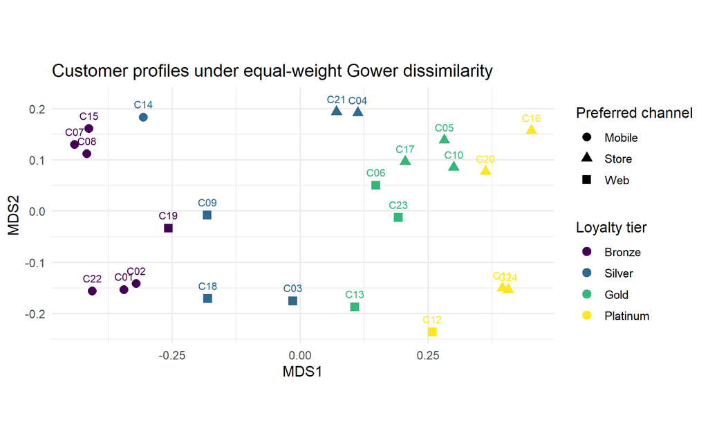

Classical MDS of the equal-weight Gower dissimilarities. The axes are arbitrary coordinate directions, not customer traits.

```r
fit <- cmdscale(d_gower, k = 2, eig = TRUE)
map <- customers |>
  transmute(customer_id, loyalty_tier, preferred_channel,
            MDS1 = fit$points[, 1], MDS2 = fit$points[, 2])

ggplot(map, aes(MDS1, MDS2, colour = loyalty_tier, shape = preferred_channel,
                label = customer_id)) +
  geom_point(size = 3) +
  geom_text(nudge_y = .025, show.legend = FALSE, size = 3) +
  coord_equal() +
  labs(title = "Customer profiles under equal-weight Gower dissimilarity",
       colour = "Loyalty tier", shape = "Preferred channel")
```

```r
map_distance <- dist(fit$points)
cor(as.vector(d_gower), as.vector(map_distance))
```

```
## [1] 0.9447721
```

The map gives a compact view of major profile contrasts. It is not complete: Gower dissimilarity is not guaranteed to be Euclidean, and two dimensions cannot preserve every pairwise distance. The correlation printed above is a descriptive diagnostic of distance reproduction, not an acceptance threshold.

# 4 3. Why arbitrary numeric codes are not valid

If Mobile = 1, Store = 2 and Web = 3, Euclidean distance says that Mobile is twice as far from Web as it is from Store. Replacing the codes with Mobile = 1, Store = 3 and Web = 2 reverses that geometry without changing the observed categories. The numerical gaps come from the coding decision, not the data. A nominal variable should enter through a same/different comparison.

# 5 4. Homework extension

## 5.1 4.1 Give recent visits double weight

```r
weight_visits <- c(age = 1, income_k_eur = 1, visits_last_month = 2,
                   loyalty_tier = 1, preferred_channel = 1, region = 1,
                   uses_discount = 1, returns_last_year = 1)
d_weighted <- daisy(profiles, metric = "gower", weights = weight_visits)

knitr::kable(head(pair_table(d_weighted), 6), digits = 3, row.names = FALSE,
             caption = "Closest pairs after giving visits double weight.")
```

Closest pairs after giving visits double weight.

| customer_1 | customer_2 | dissimilarity |
| --- | --- | --- |
| C11 | C24 | 0.011 |
| C04 | C21 | 0.038 |
| C10 | C20 | 0.051 |
| C03 | C13 | 0.087 |
| C01 | C02 | 0.092 |
| C07 | C08 | 0.095 |

The weighting is defensible only if visit frequency is genuinely twice as important for the stated segmentation purpose. It must be documented and checked as a sensitivity analysis; choosing weights merely because they create a desired visual grouping is not defensible.

## 5.2 4.2 Remove age and income

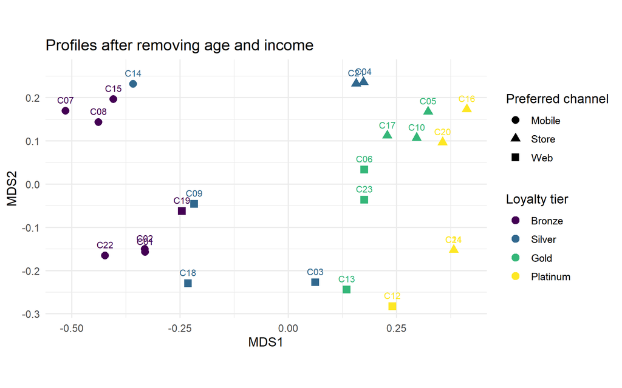

Removing age and income changes the target from demographic-plus-behavioural similarity to engagement and preference similarity.

```r
profiles_behavioural <- profiles |> select(-age, -income_k_eur)
d_behavioural <- daisy(profiles_behavioural, metric = "gower")
fit_behavioural <- cmdscale(d_behavioural, k = 2)

behavioural_map <- customers |>
  transmute(customer_id, loyalty_tier, preferred_channel,
            MDS1 = fit_behavioural[, 1], MDS2 = fit_behavioural[, 2])
ggplot(behavioural_map, aes(MDS1, MDS2, colour = loyalty_tier,
                            shape = preferred_channel, label = customer_id)) +
  geom_point(size = 3) +
  geom_text(nudge_y = .025, show.legend = FALSE, size = 3) +
  coord_equal() +
  labs(title = "Profiles after removing age and income",
       colour = "Loyalty tier", shape = "Preferred channel")
```

Removing variables changes the scientific question; it is not merely a graphical adjustment. This version compares engagement, loyalty and preferences rather than a broader demographic-plus-behavioural profile.

## 5.3 4.3 Distance-reproduction plot

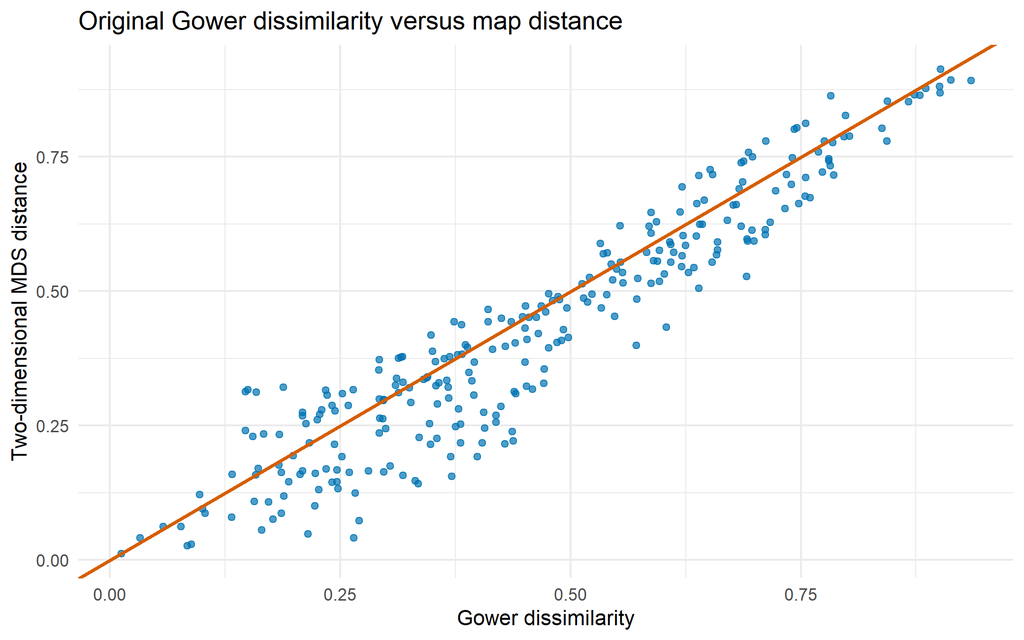

Pairs far from the diagonal are poorly reproduced by the two-dimensional map.

```r
original <- as.matrix(d_gower)
mapped <- as.matrix(map_distance)
reproduction <- tibble(
  customer_1 = rownames(original)[row(original)[upper.tri(original)]],
  customer_2 = colnames(original)[col(original)[upper.tri(original)]],
  original_distance = original[upper.tri(original)],
  map_distance = mapped[upper.tri(mapped)]
) |> mutate(absolute_error = abs(original_distance - map_distance))

ggplot(reproduction, aes(original_distance, map_distance)) +
  geom_point(colour = blue, alpha = .7) +
  geom_abline(slope = 1, intercept = 0, colour = orange, linewidth = 1) +
  labs(title = "Original Gower dissimilarity versus map distance",
       x = "Gower dissimilarity", y = "Two-dimensional MDS distance")
```

```r
knitr::kable(slice_max(reproduction, absolute_error, n = 1),
             digits = 3, row.names = FALSE,
             caption = "Pair with the largest distance-reproduction error.")
```

Pair with the largest distance-reproduction error.

| customer_1 | customer_2 | original_distance | map_distance | absolute_error |
| --- | --- | --- | --- | --- |
| C07 | C15 | 0.264 | 0.042 | 0.222 |

The pair with the largest error deserves inspection, but it is not necessarily an error in the data. It is a relationship that cannot be retained faithfully in this two-dimensional representation.

# 6 5. Example decision memo

> We compared anonymised customer profiles, excluding the identifier. We used Gower dissimilarity because the variables include numeric measures, an ordinal loyalty tier, nominal channel and region, and binary discount use. Numeric differences were scaled by observed ranges and baseline weights were one. Classical MDS gives an exploratory map in which nearby points have similar profiles under this explicit specification. The axes are not customer traits, and the map does not reproduce every dissimilarity exactly. Any weighting must be tied to a documented purpose. Customer profiling can also amplify unfair treatment or support inferences beyond the data, so the map is not an automated decision rule.

> **Note on AI assistance**

> These teaching materials were prepared with assistance from ChatGPT (OpenAI) in drafting explanations, developing examples, and generating R code. The author retains responsibility for the final content.